# Final Report on Climate Change

Max Wang

2024-04-22

# Introduction

Throughout history, human industrialization and modernity have sparked many innovations and made the standard of living on average more accessible and sustainable in the short-term. However, air temperatures on Earth have been rising since the Industrial Revolution. While natural variability plays some part, the preponderance of evidence indicates that human activities—particularly emissions of heat-trapping greenhouse gases—are mostly responsible for making our planet warmer. Due to long-term and sustained usage of fossil fuels, as well as mass animal farming, deforestation, and pollution, humans have inevitably contributed to the rise in temperatures worldwide that affect the environment and habitats we live in due to the inadvertent rise in greenhouse gas levels. Consequences of such negligence is shown in rising sea levels, increase in frequency and length of wildfires, magnitude of flooding, and more natural disasters. In this report, I will be looking at the crucial global trends in temperature from a pre-industrial period (before 1940 CE) compared to a post-industrial period (post 1940s - 2022), and determining if there exists a significant comparison between the two eras and a trend to show increased temperature change within the timeframe.

## Figure 1 - Global Land-Ocean Temperature Index

The graph below of the “Global Land-Ocean Temperature Index” using NASA GISS data illustrates that annual mean temperature anomalies have increased from 1940 CE onward. Anomalies are used to more accurately describe climate variability over larger areas than absolute temperatures do, and they give a frame of reference (pre vs post 1940) that allows more meaningful comparisons between locations and more accurate calculations of temperature trends. The temperature data set from NASA included 1880 CE as the starting point to measure land-ocean global means, more than a decade after the emergence of the industrial revolution in Britain and the U.S. Temperature trends in the pre-industrial period were relatively constant and showed no direct correlation. However, the modern period has shown that temperature anomalies have a positive relationship as time passes. Given the upward trend of the graph, there exists opportunity for temperature anomalies to accelerate as greenhouse gas emissions increase evermore and as humans ignore the imminent threat of climate change. Given the specific heat of land and water, and this graph taking both into account, there exists a potential for surface temperature on land to increase even more drastically and faster than the previous decades, despite these decades already showing a rapid increase in temperature change.

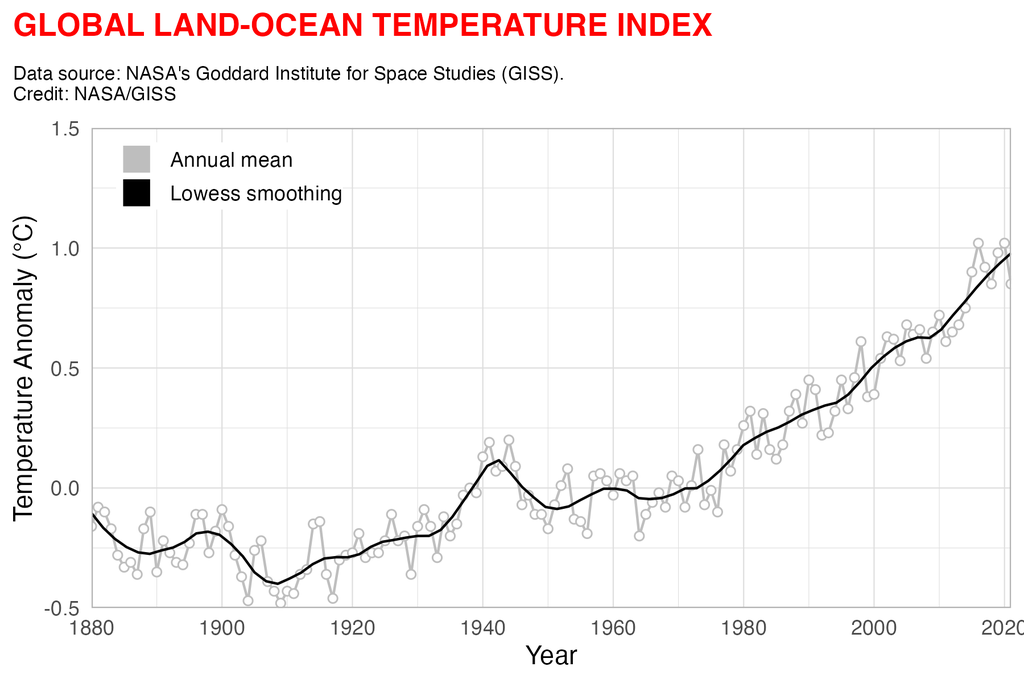

ClimateTrend

## Figure 2 - Global Temperature Change in Stripes

Figure 2 below uses stripes to illustrate global temperature change from the 1880’s to 2022, with blue being a low temperature change and red being a high temperature change. The graph shows that temperature change was once very constant and stagnant, in pre-industrial period, with blue values showing that there is unlikely to be a change in temperature (negative values). However, after increasing to zero (this leveling off could be due to the use of aerosols), and then positive values in 1980 CE, the temperature has been increasing at a fast rate ever since 1980 CE. The “warming stripes” graph ultimately shows the juxtaposition between a time of pre-industrial vs industrial growth, spurred by the Industrial Revolution, as shown by no chance for a temperature change to a high chance of temperature change in the modern period, which is only expected to change even more drastically in the upcoming decades due to the creation and systemic tools in place to burn even more fossil fuels than ever before.

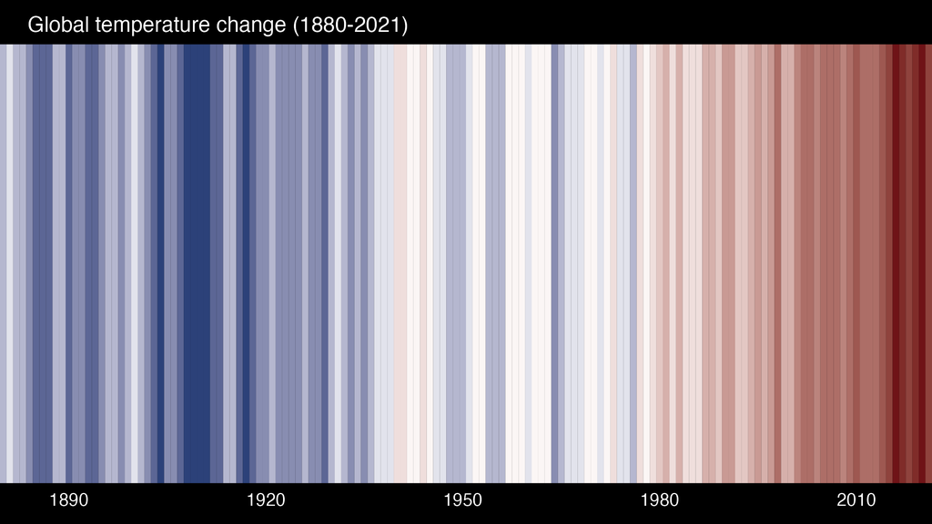

WarmingStripes

## Figure 3 - Temperature Increase in a Tornado

The graph below shows a climate tornado that effectively illustrates that the period from 1880-1980 shows relatively sparse amounts of red hued bars that represent a high temperature anomaly. Around 1980 CE, temperature change began to rapidly increase from a near-zero value to one degree Celsius today. Additionally, the closeness of the red bars to the golden bars of one degree Celsius illustrates the temperature change is increasing at a faster rate than ever before, compared to the period between 1880-1980, a period where industrial output was blooming and a preamble for the consequences in temperature to come. Although the number itself is not concerning, as we look at the tornado plot it is clear that post-1980 to current (we can refer to this period here as a period of industrial outcome), there exists an increase in global land-ocean temperature change. This trend is expected to continue to increase, perhaps exponentially, perhaps linearly, depending on the state of the nation and collective agreements. The period of industrial outcome is highly dependable on responses to previous actions or inaction to potentially reverse the effect of an accelerating climate. The “climate tornado” graph ultimately shows that since 1880 CE, average global temperatures have increased of about by one degree Celsius, and is expected to increase even more at a faster rate in the future.

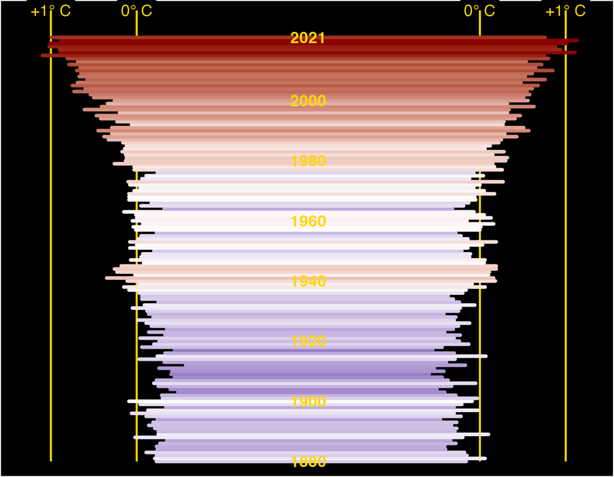

ClimateTornado

## Figure 4 Global Temperature Change Since 1880 By Month

Figure 4 of global temperature shows temperature anomaly changes since 1880 CE by month. It breaks down the change in temperature trends to illustrate a time of pre-industrial vs industrial growth. From the graph it is immediately clear that the industrial period experienced a greater variation in temperature compared to the pre-industrial period. As reflected in the line graph, global temperature change in all twelve months remained relatively constant with peaks and dips showing no observable pattern. A temperature change in the negative values during December of 1880 may simply be explained to the fact that it is colder in December than April due to seasonal changes. Despite this, as temperature changes reach the turn of the 20th century, they suddenly become more cyclic and more comparable to the baseline of 1880 CE. Despite a lack of data representing a larger scope pre-1880, the sudden drive in temperature change can be attributed to human activity that have directly led to the warming of the environment. This graph effectively illustrates this with higher peaks in temperature change between January-December in the industrial period versus the pre-industrial period. The peaks are generally higher and illustrate a positive temperature change and one degree Celsius temperate change, compared to a near-zero or negative temperature change in the pre-industrial period. The graph also illustrates the temperature change becomes negative to positive between the 1920’s and 1940’s, according to temperature anomalies. This graph ultimately demonstrates that as time has passed since 1880 CE, temperatures have increased on average with respect to 1880 CE as the baseline, in all twelve of the months. All the lines for each individual year show rapid warming in the past few decades, and all show the last decade as the warmest.

“According to the 2017 U.S. Climate Science Special Report, if yearly emissions continue to increase rapidly, as they have since 2000, models project that by the end of this century, global temperature will be at least 5 degrees Fahrenheit warmer than the 1901-1960 average, and possibly as much as 10.2 degrees warmer. If annual emissions increase more slowly and begin to decline significantly by 2050, models project temperatures would still be at least 2.4 degrees warmer than the first half of the 20th century, and possibly up to 5.9 degrees warmer” (https://earthobservatory.nasa.gov/world-of-change/global-temperatures). This creates an impetus to not only create solutions to the issue of climate change, but find ways to reverse previous issues and remediate the current situation.

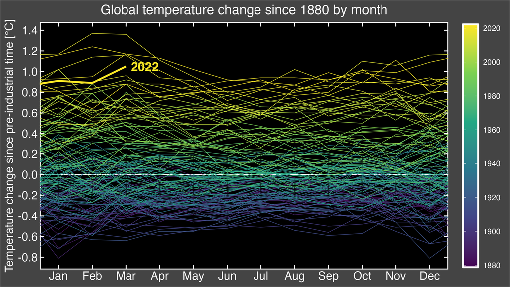

ClimateLines

# Conclusion

All of this is to say that the effects and causes of climate change are extremely wide-ranging, and unless something is done to address the issue at hand today, the global change in temperature will only accelerate to a level that could mean danger for human species and biodiversity.